# Sysnopsis

The data revolution has a lot to do with the fact that now we are able to collect all sorts of data about people who buy something on our site as well as people who don’t. This gives us tremendous opportunity to understand what’s working well (and potentially scale it even further) and what’s not working well (and fix it).

In this report we analyse and predict the conversion rate of users who hit our website: whether they converted or not as well as some of their characteristics such as their country, the marketing channel, their age, whether they are repeat users and the number of pages visited during that session.

Before we dive into the data, let’s take a step back and think about what we’re about to do. Effectively, let’s form some intution about what we may see in the data so we don’t merely report what the data is telling us. The intution we develop now will act as guide as we navigate the data so that we don’t fall into the data mining trap.

So first, let’s begin with the end in mind:

1. What is the purpose of this analysis/prediction model? **Data Science take home challenge to assess a candidates competency with a data analysis assignment.**

Second, now let’s begin with the beginning:

2. What problem are we trying to solve? **Classification problem to predict which customers would convert on our website.**

### Below are some additional questions we should/could ask after reading the assignment problem statement.

1. How was the data captured? This usually informs us of potetnial biases that may be inherently embedded in the data which can ultimately lead us to the appropriate variables we would need to feature engineer or choose a model that best captures the phenomenon we’re looking to model. E.g., classification model with Logistic Regression or Random Forest
2. What was happening at the time the data was captured?
3. Does each record capture a unique user?
   - 3a. How many records are in the dataset?
   - 3b. What does each record represent?
   - 3c. How many variables in the dataset?
4. Which company/industry is the data from?
5. Customers don’t typically supply age information upon sign-in. They could provide incorrect age.
6. What is the conversion rate?
7. What day of the week was the data captured? Weekday visitors may look different than weekend.
8. Was the data sampled? If so, there maybe biases in the sampling.

### Concluding/Working hypothesis after preliminary research:

1. Proceed with caution from the prediction or analysis from this dataset. The dataset doesn’t seem to be grounded in too many cogent business practices.
2. I could see major issues with this data:
   - 2a. user session on average about 30 mins.
   - 2b. What if a user visited the site 2 or 3 times in a day that gets captured in several sessions?
3. An individual session - even though they convert may not provide enough info on the user
4. What about the platform the user converted on? mobile tends to be higher conversion rate than desktop?
5. People browse on desktop and convert on mobile at some ecommerce companies. I suspect it will depend on how convenient the product is for shopping
6. There also seem to be leakage in the data. If the prediction model is supposed to be used in real time predicction on the website, the variable total_pages_vsited is only available after the consumer has ended their session. So even if it turns out to be a great predictor, it won’t be available until the customer leaves the site. A workaround could be: take the distrition of pages visted over a time period as a work around.

### Now that we have a working hypothesis, let’s take a look at the data.

1. Let’s take a look at the data and see if our initial hypothesis is wrong. OR better yet, reveal something to us that we just don’t know about. This should be fun.

# Data Processing

### Load the require packages

```r
library(ggplot2)
library(ggplot2)
library(reshape2)
library(plyr)
library(knitr)
require(randomForest)
require(rpart)
require(dplyr)
```

We first read the conversion rate data into R:

```r
conversion <- read.table("conversion_data.csv", header=TRUE, sep = ",")
```

The data look something like this:

```r
head(conversion)
```

```
##   country age new_user source total_pages_visited converted
## 1      UK  25        1    Ads                   1         0
## 2      US  23        1    Seo                   5         0
## 3      US  28        1    Seo                   4         0
## 4   China  39        1    Seo                   5         0
## 5      US  30        1    Seo                   6         0
## 6      US  31        0    Seo                   1         0
```

### Now that we have our data loaded into R. Let’s do some data munging on the data. However, before we do so, let’s take a look at the structure.

```r
str(conversion)
```

```
## 'data.frame':    316200 obs. of  6 variables:
##  $ country            : Factor w/ 4 levels "China","Germany",..: 3 4 4 1 4 4 1 4 3 4 ...
##  $ age                : int  25 23 28 39 30 31 27 23 29 25 ...
##  $ new_user           : int  1 1 1 1 1 0 1 0 0 0 ...
##  $ source             : Factor w/ 3 levels "Ads","Direct",..: 1 3 3 3 3 3 3 1 2 1 ...
##  $ total_pages_visited: int  1 5 4 5 6 1 4 4 4 2 ...
##  $ converted          : int  0 0 0 0 0 0 0 0 0 0 ...
```

Looking at the structure of the data, we see that the variable converted and new users are interger. These should be categorial variables. Let’s use R factor function to convert these to categorial variables.

```r
conversion$new_user <- as.factor(conversion$new_user)
conversion$converted <- as.factor(conversion$converted)
```

Now, let’s inspect the data to look for weird behavior/wrong data. Data is never perfect in real life and requires to be cleaned. Often takehome challenges have wrong data which has been put there on purpose. Identifying the wrong data and dealing with it is part of the challenge.

# Data Exploration

R summary function is usually the best place to start:

```r
summary(conversion)
```

```
##     country            age         new_user      source
##  China  : 76602   Min.   : 17.00   0: 99456   Ads   : 88740
##  Germany: 13056   1st Qu.: 24.00   1:216744   Direct: 72420
##  UK     : 48450   Median : 30.00              Seo   :155040
##  US     :178092   Mean   : 30.57
##                   3rd Qu.: 36.00
##                   Max.   :123.00
##  total_pages_visited converted
##  Min.   : 1.000      0:306000
##  1st Qu.: 2.000      1: 10200
##  Median : 4.000
##  Mean   : 4.873
##  3rd Qu.: 7.000
##  Max.   :29.000
```

### A few quick observations:

1. The site is probably a US site, although it does have a large Chinese user base. The user base is also relatively young.
2. Conversion rate at around 3%. This is approximately industry standard.
3. Summary reveals that a user has age of 123. Did this user purchase? They self disclosed age, it could be wrong. Do we drop it or impute it?

Let’s take a look at age closely.

```r
sort(unique(conversion$age), decreasing=TRUE)
```

```
##  [1] 123 111  79  77  73  72  70  69  68  67  66  65  64  63  62  61  60
## [18]  59  58  57  56  55  54  53  52  51  50  49  48  47  46  45  44  43
## [35]  42  41  40  39  38  37  36  35  34  33  32  31  30  29  28  27  26
## [52]  25  24  23  22  21  20  19  18  17
```

Distribution of Visitor Age

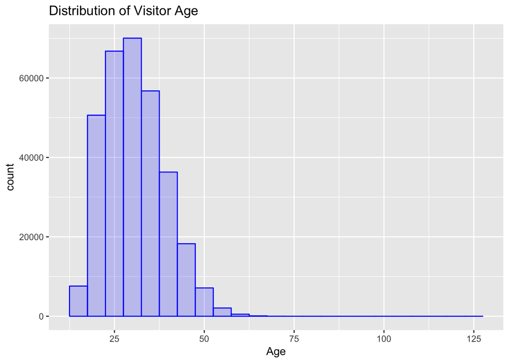

```r
qplot(conversion$age,
      geom="histogram",
      binwidth = 5,
      main = "Distribution of Visitor Age",
      xlab = "Age",
      fill=I("blue"),
      col=I("blue"),
      alpha=I(.2))
```

Those 123 and 111 values seem unrealistic. How many users are we talking about:

```r
subset(conversion, age>79)
```

```
##        country age new_user source total_pages_visited converted
## 90929  Germany 123        0    Seo                  15         1
## 295582      UK 111        0    Ads                  10         1
```

It is just 2 users! In this case, we can remove them, it won’t have much effect on our analysis/prediction. In general, depending on the problem, we can:

1. Remove the entire row saying we don’t trust those data point and treat those values as NAs
2. If there is a pattern, try to figure out what went wrong. In doubt, always go with removing the row. It is the safest choice.

We probably also want to emphasize in the text that wrong data is worrisome and can be an indicator of some bug in the logging code. **This is exactly in line with some of the intuition we formed before even looking at the data**. This is an instance where can metnion that you’d like to talk with the software engineer who implemented the code to see if, perhaps, there are some bugs which affect the data significantly. You can use this as an opportunity to follow-up on other questions you may have. Anyway, here is probably just users who put in wrong data. So let’s remove them:

```r
conversion <- subset(conversion, age<80)
```

Now, let’s quickly investigate the variables and how their distribution differs for the two classes. This will help us understand whether there is any information in our data in the first place and get a sense of the data.

## Never start by blindly building a machine learning/predictive model.

Always first **form a working hypothesis** and then **get a sense of the data.** Let’s just pick a couple of variables of interest as an example, but you should do it with all:

Here it clearly looks like Chinese convert at a much lower rate than other countries!

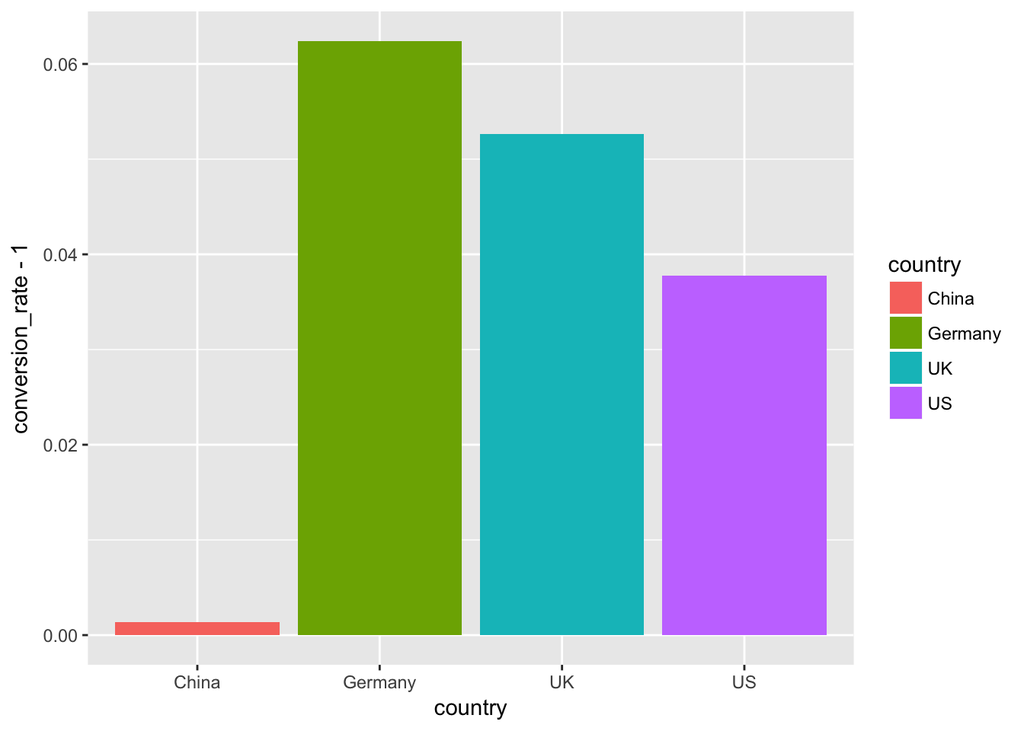

```r
conversion$converted <- as.numeric(conversion$converted)
conversion_country <- conversion %>%
                    group_by(country) %>%
                    summarise(conversion_rate = mean(converted))
ggplot(data = conversion_country, aes(x=country, y = conversion_rate - 1)) +
      geom_bar(stat = "identity", aes(fill=country))
```

Definitely spending more time on the site implies higher probability of conversion!

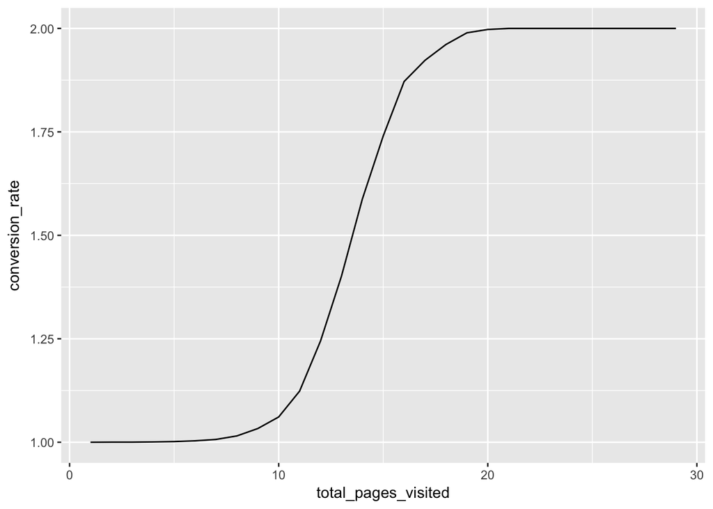

```r
conversion_pages = conversion %>%
  group_by(total_pages_visited) %>%
  summarise(conversion_rate = mean(converted))
qplot(total_pages_visited, conversion_rate, data=conversion_pages, geom="line")
```

Leakage: when the data you are using to train a machine learning algorithm happens to have the information you are trying to predict. Total pages visited is a high predictor of conversion but we won’t know that until the user leaves the site. Depending on the application, we have to careful. For our case, let’s include this in the text to the product and/or marketing team.

# Data Modeling

Let’s now build a model to predict conversion rate. Outcome is binary and we care about insights to give product and marketing team some ideas. We should probably choose from among the following models:

1. Logistic regression
2. Decision Trees
3. Random Forest in combination with partial dependence plots

I am going to pick a random forest to predict conversion rate. Reasons:

1. It usually requires very little time to optimize it (its default params are often close to the best ones)
2. It is strong with outliers, irrelevant variables, continuous and discrete variables.

I will use Random Forest to predict conversion, then I will use its partial dependence plots and variable importance to get insights about how it got information from the variables. Also, I will build a simple tree to find the most obvious user segments to see if they agree with Random Forest partial dependence plots.

First, “converted” should really be a factor aka categorial variable here. So let’s change it:

```r
conversion$converted = as.factor(conversion$converted)
```

Create test/training set with a standard 66% split (if the data were too small, I would cross-validate) and then build the forest with standard values for the 3 most important parameters (100 trees, trees as large as possible, 3 random variables selected at each split).

```r
train_sample = sample(nrow(conversion), size = nrow(conversion)*0.66)
train_data = conversion[train_sample,]
test_data = conversion[-train_sample,]
rf = randomForest(y=train_data$converted, x = train_data[, -ncol(train_data)],
                  ytest = test_data$converted, xtest = test_data[, -ncol(test_data)],
                  ntree = 100, mtry = 3, keep.forest = TRUE, classwt = c(0.7,0.3))
```

```r
rf
```

```
##
## Call:
##  randomForest(x = train_data[, -ncol(train_data)], y = train_data$converted,      xtest = test_data[, -ncol(test_data)], ytest = test_data$converted,      ntree = 100, mtry = 3, classwt = c(0.7, 0.3), keep.forest = TRUE)
##                Type of random forest: classification
##                      Number of trees: 100
## No. of variables tried at each split: 3
##
##         OOB estimate of  error rate: 3.19%
## Confusion matrix:
##        1    2 class.error
## 1 196330 5650  0.02797307
## 2   1005 5705  0.14977645
##                 Test set error rate: 3%
## Confusion matrix:
##        1    2 class.error
## 1 101301 2719   0.0261392
## 2    509 2979   0.1459289
```

Let’s start checking variable importance:

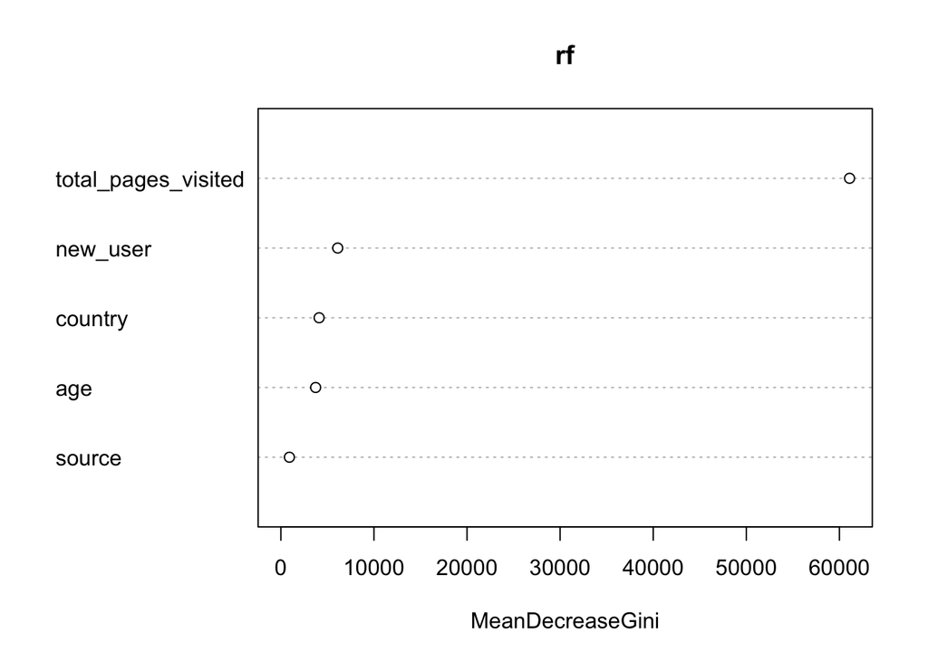

```r
varImpPlot(rf,type=2)
```

```r
rf = randomForest(y=train_data$converted, x = train_data[, -c(5, ncol(train_data))],
ytest = test_data$converted, xtest = test_data[, -c(5, ncol(train_data))],
ntree = 100, mtry = 3, keep.forest = TRUE, classwt = c(0.7,0.3))
rf
```

```
##
## Call:
##  randomForest(x = train_data[, -c(5, ncol(train_data))], y = train_data$converted,      xtest = test_data[, -c(5, ncol(train_data))], ytest = test_data$converted,      ntree = 100, mtry = 3, classwt = c(0.7, 0.3), keep.forest = TRUE)
##                Type of random forest: classification
##                      Number of trees: 100
## No. of variables tried at each split: 3
##
##         OOB estimate of  error rate: 14.08%
## Confusion matrix:
##        1     2 class.error
## 1 175710 26270   0.1300624
## 2   3109  3601   0.4633383
##                 Test set error rate: 14.09%
## Confusion matrix:
##       1     2 class.error
## 1 90446 13574   0.1304941
## 2  1579  1909   0.4526950
```

Accuracy went down, but that’s fine. The model is still good enough to give us insights. Let’s recheck variable importance:

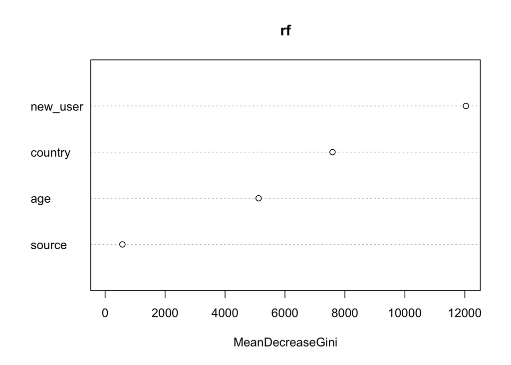

```r
varImpPlot(rf,type=2)
```

Interesting! New user is the most important one. Source doesn’t seem to matter at all.

Let’s check partial dependence plots for the 4 vars:

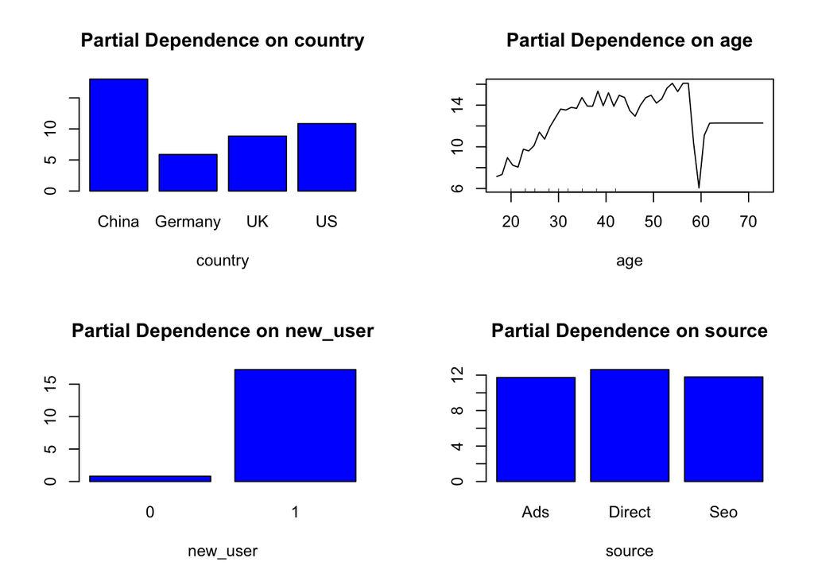

```r
op <- par(mfrow=c(2, 2))
partialPlot(rf, train_data, country, 1)
partialPlot(rf, train_data, age, 1)
partialPlot(rf, train_data, new_user, 1)
partialPlot(rf, train_data, source, 1)
```

In partial dependence plots, we just care about the trend, not the actual y value. So this shows that:

1. Users with an old account are much better than new users
2. China is really bad, all other countries are similar with Germany being the best
3. The site works very well for young people and bad for less young people (>30 yrs old)
4. Source is irrelevant

Let’s now build a simple decision tree and check the 2 or 3 most important segments:

```r
tree = rpart(conversion$converted ~ ., conversion[, -c(5,ncol(data))],
                    control = rpart.control(maxdepth = 3),
                      parms = list(prior = c(0.7, 0.3))
                      )
tree
```

```
## n= 316198
##
## node), split, n, loss, yval, (yprob)
##       * denotes terminal node
##
##  1) root 316198 94859.4000 1 (0.70000000 0.30000000)
##    2) new_user=1 216744 28268.0600 1 (0.84540048 0.15459952) *
##    3) new_user=0 99454 66591.3400 1 (0.50063101 0.49936899)
##      6) country=China 23094   613.9165 1 (0.96445336 0.03554664) *
##      7) country=Germany,UK,US 76360 50102.8100 2 (0.43162227 0.56837773)
##       14) age>=29.5 38341 19589.5200 1 (0.57227507 0.42772493) *
##       15) age< 29.5 38019 23893.0000 2 (0.33996429 0.66003571) *
```

## Conclusion

### A simple small tree confirms exactly the random forest findings. Some conclusions and suggestions:

1. The site is working very well for young users. We could recommend to marketing to advertise and use marketing channel which are more likely to reach young people.
2. The site is working very well for Germany in terms of conversion. But the summary showed that there are few Germans coming to the site: way less than UK, despite a larger population. Again, marketing should get more Germans. Big opportunity.
3. Users with old accounts do much better. Targeted emails with offers to bring them back to the site could be a good idea to try.
4. Something is wrong with the Chinese version of the site. It is either poorly translated, doesn’t fit the local culture, some payment issue or maybe it is just in English! Given how many users are based in China, fixing this should be a top priority. Huge opportunity.
5. Maybe go through the UI and figure out why older users perform so poorly? From 30 y/o conversion clearly starts dropping.
6. If I know someone has visited many pages, but hasn’t converted, she almost surely has high purchase intent. I could email her targeted offers or sending her reminders. Overall, these are probably the easiest users to make convert.

### As you can see, conclusions usually end up being about:

1. tell marketing to get more of the good performing user segments
2. tell product to fix the experience for the bad performing ones